# Clase 12. Filtro HP

Benjamin Oliva & Omar Alfaro-Rivera

14/10/2021

## Filtro Hodrick & Prescott (1997)

El articulo original es una discusion respecto de como modelar la brecha del PIB: “Modelling the output gap - Hodrick-Prescott filter”. Estos modelos fueron desarrollados por Hodrick & Prescott (1997), quienes sugieren algunos valores - constantes - para el coeficiente de castigo por desviaciones respecto de la trayectoria de largo plazo ($\lambda$):

- $\lambda$ = 100 for yearly data
- $\lambda$ = 1600 for quarterly data
- $\lambda$ = 14400 for monthly data

# Importamos Datos desde un archivo de R:

Los datos “cargados” son los originales y los ajustados por estacionalidad. Los cuales son:

- INPC: Indice Nacional de Precios al Consumidor (2QJul2018 = 100)
- TC: Tipo de Cambio FIX
- CETE28: Tasa de rendimiento promedio mensual de los Cetes 28, en por ciento anual
- IGAE: Indicador global de la actividad económica (2013 = 100)
- IPI: Industrial Production Index (2012 = 100)

```r
load("Datos_Ad.RData")

head(Datos_Ad)
```

```
##        FECHA     INPC     TC CETE28    IGAE     IPI  INPC_Ad  TC_Ad CETE28_Ad
## 1 2000-01-01 44.93083 9.4878  16.19 77.9300 90.7125 44.76927 9.4878     16.19
## 2 2000-02-01 45.32938 9.4252  15.81 77.3673 91.4934 45.18269 9.4252     15.81
## 3 2000-03-01 45.58068 9.2876  13.66 80.3580 93.1033 45.40063 9.2876     13.66
## 4 2000-04-01 45.84002 9.3903  12.93 77.0076 91.8422 45.70340 9.3903     12.93
## 5 2000-05-01 46.01138 9.5158  14.18 82.3433 92.1629 46.08263 9.5158     14.18
## 6 2000-06-01 46.28392 9.8295  15.65 81.5415 95.1094 46.42374 9.8295     15.65
##    IGAE_Ad   IPI_Ad
## 1 79.94685 91.61113
## 2 78.64110 91.76081
## 3 79.27218 92.38739
## 4 79.26164 92.92595
## 5 79.84777 92.75444
## 6 79.82687 92.97595
```

## Conversion a series de tiempo:

```r
INPC <- ts(Datos_Ad$INPC_Ad, start = c(2000, 1), freq = 12)

TC <- ts(Datos_Ad$TC_Ad, start = c(2000, 1), freq = 12)
```

## Filtro Hodrick-Prescott:

### INPC:

```r
#?hpfilter

INPC_hpf <- hpfilter(INPC, freq = 14400)

names(INPC_hpf)
```

```
##  [1] "cycle"   "trend"   "fmatrix" "title"   "xname"   "call"    "type"
##  [8] "lambda"  "method"  "x"
```

```r
INPC_hpf$cycle
```

```
##               Jan          Feb          Mar          Apr          May
## 2000 -0.503666517 -0.325711299 -0.343186051 -0.275746751 -0.131673298
## 2001  0.319237289  0.081947217  0.123993394  0.191673392  0.307201663
## 2002 -0.031765861 -0.257612834 -0.252319282 -0.129611371  0.014688898
## 2003  0.062495027  0.025669617  0.119053529  0.081929062 -0.007852287
## 2004 -0.098277877  0.052047588  0.006095760 -0.016358787 -0.036336989
## 2005  0.098281332  0.117616255  0.151817010  0.274129836  0.284847360
## 2006  0.086773947  0.001994549 -0.155795836 -0.141192486 -0.236038022
## 2007  0.007384662 -0.021864052 -0.153134089 -0.270460440 -0.404898815
## 2008 -0.539874638 -0.589439093 -0.430032334 -0.372454308 -0.274138573
## 2009  0.334973037  0.229128284  0.299330243  0.476950945  0.479396350
## 2010  0.270090506  0.432829031  0.635951423  0.389152799  0.184631452
## 2011  0.058886827  0.092683127 -0.058786442 -0.043764692 -0.320317967
## 2012  0.196597446  0.099904025 -0.153496469 -0.357799790 -0.320583786
## 2013 -0.202761722 -0.070692789  0.213641848  0.329266548  0.354547591
```

[output cut: 57 more lines]

```r
INPC_hpf$trend
```

```
##            Jan       Feb       Mar       Apr       May       Jun       Jul
## 2000  45.27294  45.50840  45.74382  45.97915  46.21430  46.44918  46.68368
## 2001  48.07646  48.30528  48.53296  48.75945  48.98471  49.20872  49.43148
## 2002  50.74306  50.95783  51.17158  51.38434  51.59610  51.80683  52.01652
## 2003  53.25310  53.45583  53.65771  53.85880  54.05913  54.25879  54.45783
## 2004  55.64165  55.83739  56.03265  56.22743  56.42169  56.61542  56.80861
## 2005  57.95523  58.14444  58.33329  58.52190  58.71036  58.89880  59.08738
## 2006  60.23133  60.42572  60.62163  60.81926  61.01874  61.22026  61.42393
## 2007  62.69721  62.91884  63.14340  63.37098  63.60167  63.83552  64.07256
## 2008  65.56019  65.81819  66.07866  66.34135  66.60599  66.87229  67.13993
## 2009  68.75605  69.02437  69.29177  69.55805  69.82305  70.08664  70.34872
## 2010  71.88731  72.13808  72.38727  72.63493  72.88114  73.12602  73.36972
## 2011  74.81439  75.05348  75.29246  75.53147  75.77066  76.01018  76.25014
## 2012  77.70238  77.94642  78.19094  78.43590  78.68127  78.92699  79.17296
## 2013  80.64967  80.89531  81.14063  81.38553  81.62996  81.87386  82.11721
```

[output cut: 33 more lines]

```r
INPC_hpf$lambda
```

```
## [1] 14400
```

```r
INPC_hpf$x
```

```
##            Jan       Feb       Mar       Apr       May       Jun       Jul
## 2000  44.76927  45.18269  45.40063  45.70340  46.08263  46.42374  46.69991
## 2001  48.39570  48.38723  48.65695  48.95112  49.29191  49.48353  49.45256
## 2002  50.71130  50.70021  50.91926  51.25473  51.61079  51.94368  52.18248
## 2003  53.31559  53.48150  53.77677  53.94073  54.05128  54.18811  54.34507
## 2004  55.54337  55.88944  56.03875  56.21107  56.38535  56.57853  56.79179
## 2005  58.05351  58.26205  58.48511  58.79603  58.99520  59.04946  59.33153
## 2006  60.31810  60.42771  60.46584  60.67806  60.78271  60.94923  61.15563
## 2007  62.70460  62.89698  62.99027  63.10052  63.19677  63.38790  63.68660
## 2008  65.02031  65.22876  65.64863  65.96890  66.33186  66.72413  67.11927
## 2009  69.09102  69.25350  69.59110  70.03500  70.30245  70.55552  70.76732
## 2010  72.15740  72.57091  73.02323  73.02408  73.06577  73.16897  73.34129
## 2011  74.87328  75.14616  75.23367  75.48771  75.45035  75.56918  75.93708
## 2012  77.89897  78.04633  78.03744  78.07810  78.36069  78.83739  79.28368
## 2013  80.44691  80.82462  81.35427  81.71480  81.98451  82.05002  82.03196
```

[output cut: 33 more lines]

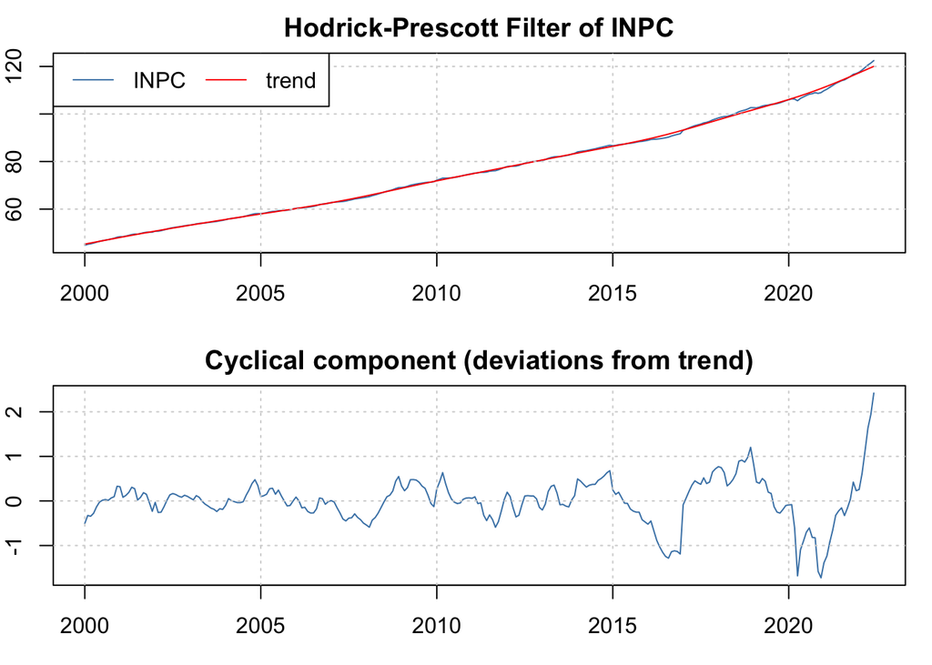

```r
plot(INPC_hpf)
```

```r
INPC_Cycle <- INPC_hpf$cycle

INPC_Trend <- INPC_hpf$trend
```

### TC:

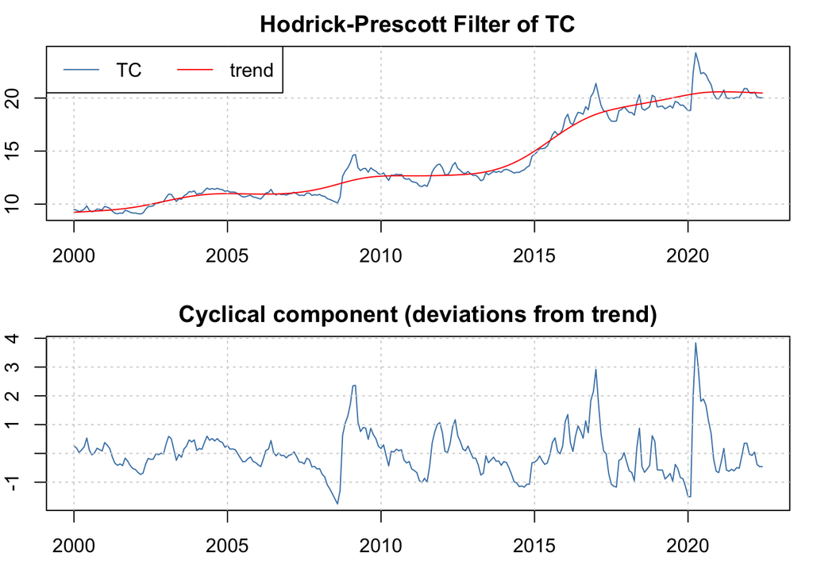

```r
TC_hpf <- hpfilter(TC, freq = 14400)

plot(TC_hpf)
```

```r
TC_Cycle <- TC_hpf$cycle

TC_Trend <- TC_hpf$trend
```

# DataFrame:

```r
Datos_HPF <- cbind(Datos_Ad$FECHA,
                  data.frame(cbind(INPC,
                                   INPC_Trend,
                                   INPC_Cycle,
                                   TC,
                                   TC_Trend,
                                   TC_Cycle)))
```

# Hodrick-Prescott planteado por St-Amant & van Norden

Método modificado de HP consiste en minimizar los valores de la serie $\{ \tau_t \}_{t=1}^T$:
$$\sum_{t=1}^T (y_t - \tau_t)^2 + \lambda
\sum_{t=2}^{T-1} [(\tau_{t+1} - \tau_t) - (\tau_t - \tau_{t-1})]^2 +
\lambda_{ss} \sum_{t=T-j}^{T} [\Delta \tau_t - u_{ss}]$$

Donde $\lambda$ es una parámetro fijo (determinado ex-ante), $\tau_t$ es un componente de tendencia de $y_t$, y los nuevos parámetros son $u_{ss}$ y $\lambda_{ss}$ ajustadas por el procedimiento de Marcet y Ravn (2004).

Este procedimiento asume que parte del filtro HP y que esta versión tiene el problema de pérdida de información al final y al principio de la muestra. La razón es que es un procedimeinto univariado que requiere de mucha información futura y pasada para mejorar el ajuste.

El compoenente adicional al filtro HP es un componente de castigo por desviaciones de la tasa de crecimiento de largo plazo, $u_{ss}$.

El proceso de selección de $\lambda_{ss}$ es e propuesto por Marcet y Ravn (2004), el cual consiste en utilizar un $\lambda$ convencional y el filtro HP convencional para estimar la siguiente función:
$$F(\lambda) = \frac{\sum_{t=2}^{T-1} ((\tau_{t+1}
- \tau_t) - (\tau_t - \tau_{t-1}))^2}{\sum_{t=1}^T (y_t -
\tau_t)^2}$$

Entonces el valor de $\lambda_{ss}$ será aquel que:
$$F(\lambda_{ss}) = \frac{\sum_{t=2}^{T-1}
((\tau_{t+1} - \tau_t) - (\tau_t - \tau_{t-1}))^2}{\sum_{t=1}^T (y_t -
\tau_t)^2} = F(\lambda)$$

nota: Antón (2009) estimó $\lambda_{ss} = 1096$ para datos trimestrales del PIB.

```r
st_amant_van_norden_filter <- function(ts_data) {

  # Calculate the variance of the series
  variance <- var(ts_data)

  # Calculate the first difference of the series
  diff_ts <- diff(ts_data)

  # Calculate the variance of the first difference of the series
  variance_diff <- var(diff_ts)

  # Calculate lambda based on the St-Amant and Van Norden formula
  lambda <- variance / variance_diff

  # Apply the Hodrick-Prescott filter with the computed lambda
  HP_Filter_StAmantVanNorden <- hpfilter(ts_data, freq = lambda)

  return(HP_Filter_StAmantVanNorden)
}
```

### Aplicando a una serie:

```r
IGAE <- ts(Datos_Ad$IGAE, start = c(2000, 1), freq = 12)

st_amant_van_norden_filter(IGAE)
```

```
##
## Title:
##  Hodrick-Prescott Filter
##
## Call:
##  hpfilter(x = ts_data, freq = lambda)
##
## Method:
##  hpfilter
##
## Filter Type:
##  lambda
##
## Series:
##  ts_data
##
##          ts_data  Trend      Cycle
## Jan 2000   77.93  77.78   0.154254
## Feb 2000   77.37  78.40  -1.036494
## Mar 2000   80.36  79.04   1.313398
## Apr 2000   77.01  79.63  -2.617591
## May 2000   82.34  80.18   2.162076
## Jun 2000   81.54  80.53   1.009660
## Jul 2000   79.63  80.68  -1.045322
## Aug 2000   81.19  80.69   0.498424
## Sep 2000   80.16  80.58  -0.413736
## Oct 2000   80.81  80.37   0.439230
## Nov 2000   80.92  80.07   0.846685
## Dec 2000   79.50  79.71  -0.216148
## Jan 2001   79.42  79.41   0.009919
## Feb 2001   76.42  79.26  -2.838147
## Mar 2001   80.77  79.34   1.430501
## Apr 2001   77.53  79.51  -1.978816
## May 2001   81.78  79.75   2.033890
## Jun 2001   80.61  79.87   0.737800
## Jul 2001   79.33  79.85  -0.521155
## Aug 2001   80.59  79.72   0.864527
## Sep 2001   78.27  79.49  -1.225042
## Oct 2001   79.97  79.23   0.741735
## Nov 2001   80.09  78.90   1.192192
```

[output cut: 232 more lines]

```
## Apr 2021  108.08 109.27  -1.187230
## May 2021  112.06 109.51   2.546286
## Jun 2021  111.19 109.46   1.733411
## Jul 2021  109.89 109.15   0.740973
## Aug 2021  107.25 108.79  -1.537594
## Sep 2021  104.27 108.63  -4.360147
## Oct 2021  108.49 108.81  -0.317352
## Nov 2021  112.97 109.09   3.880799
## Dec 2021  112.33 109.22   3.110568
## Jan 2022  107.32 109.26  -1.942807
## Feb 2022  105.26 109.54  -4.281399
## Mar 2022  111.97 110.22   1.753432
## Apr 2022  109.56 111.10  -1.535515
## May 2022  114.47 112.13   2.339516
## Jun 2022  112.92 113.15  -0.226699
```

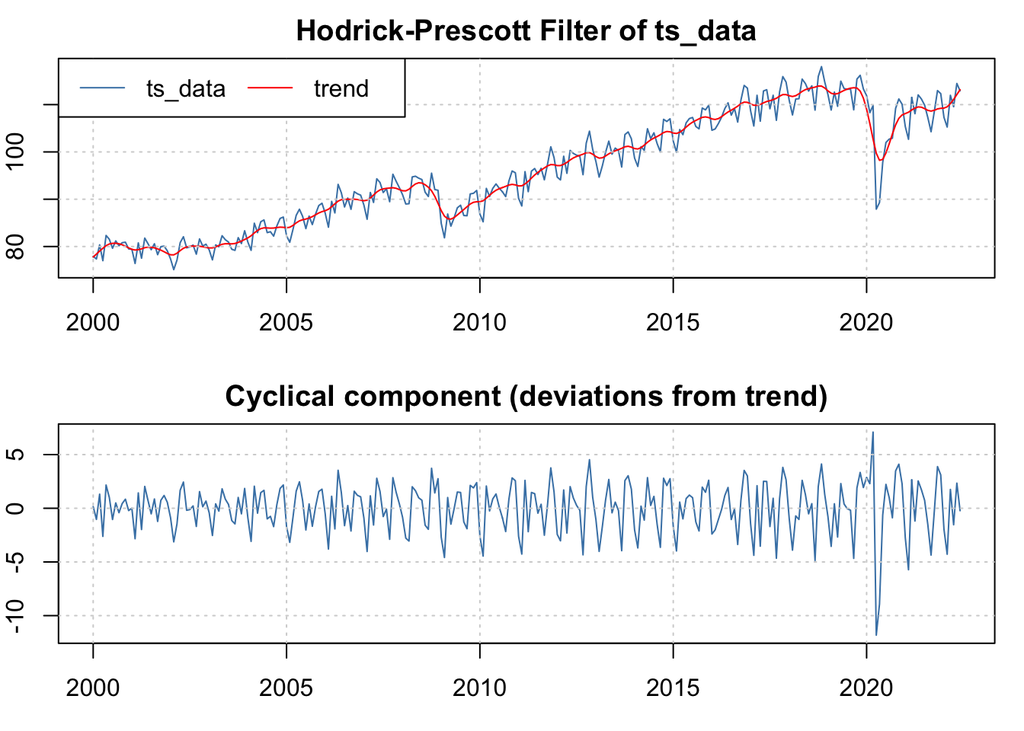

```r
IGAE_hpf_SAvN <- st_amant_van_norden_filter(IGAE)

plot(IGAE_hpf_SAvN)
```

```r
IGAE_Cycle <- IGAE_hpf_SAvN$cycle

IGAE_Trend <- IGAE_hpf_SAvN$trend
```